# Mario Muuk

```
                    Python/Java developer
```

##### https://github.com/DrSuperMario

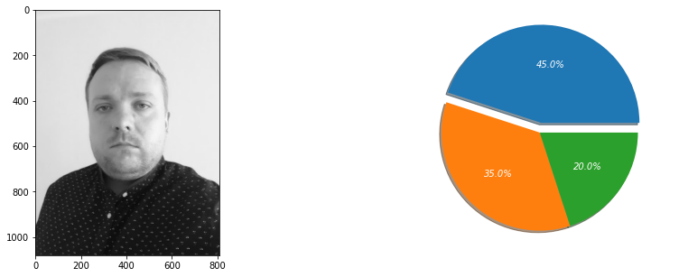

```python
import configparser; personal=configparser.ConfigParser(); personal.read('knowhow.ini');
import matplotlib.pyplot as plt; from brain.knoweledge import pic, tabel_of_know; import pandas as pd
fig, ax = plt.subplots(1,2, figsize=(15,5)); ax[0].imshow(pic); plt.rcParams.update({'text.color' : "white",'axes.labelcolor' : "white",'font.style':"oblique"})
ax[1].pie((personal['PARAMS']['Numbers'].split(",")), labels=personal['SKILLS']['Language'].split(","), explode=(0.1,0,0), shadow=True, autopct='%1.1f%%');
```

###### Hi, my name is Mario I am an aspiring software developer whose focus is on the field of Data Science and Back-End development.

### Skills && Expertise

```python
tabel_of_know()
```

| Languages | Tools | Cloud | Enviroments | Frameworks | Setup | Other |
| --- | --- | --- | --- | --- | --- | --- |
| JAVA | VSCode | DigitalOcean | Windows | Flask | HP Pavilion 15 | Machine Learning |
| Python | Intellij | Heroku | Ubuntu | AndroidAPI | Raspberry pi4B | Deep Learning |
| SQL/HTML/CSS | Android Studio | TravisCI | ArchLinux | TensorFlow | Raspberry pi400 | Data Science |
| Octave | Postman |  |  | NLTK | RaspberryZero |  |
|  | Octave |  |  |  |  |  |
|  | PowerShell |  |  |  |  |  |

#### My Strong sides:

- Great communication and collaboration skills
- solid attention to detail
- Analytical thinking
- A good knowledge of English
- communication, and reliability
- I always strive to continually improve my technical and developmental skills

### My weak sides:

- Sometimes slow to answer emails. But I am improving my speed :)
- Linux commands that i have to google over and over

### Professional Training

**Python for Financial Analysis and Algorithmic Trading**

- Date: April 28, 2020
- Lenght: 17 total hours
- Where: Udemy, Jose Portilla
- https://pythonslack.com/static/courses/python_finance.jpg*

**Machine Learning, Data Science and Deep Learning with Python**

- Date: May 6, 2020
- Lenght: 14.5 total hours
- Where: Udemy, Sundog Education by Frank Kane
- https://pythonslack.com/static/courses/python_deeplearning.jpg*

**Data Science: Deep Learning in Python**

- Date: May 11, 2020
- Lenght: 11 total hours
- Where: Udemy, Lazy Programmer inc.
- https://pythonslack.com/static/courses/python_deeplearningTwo.jpg*

**REST APIs with Flask and Python**

- Date: May 23, 2020
- Lenght: 17 total hours
- Where: Udemy, Teclado by Jose Salvatierra
- https://pythonslack.com/static/courses/python_restapI.jpg*

**Automated Software Testing with Python**

- Date: June 15, 2020
- Lenght: 13.5 total hours
- Where: Udemy, Teclado by Jose Salvatierra
- https://pythonslack.com/static/courses/python_testing.jpg*

**Complete Tensorflow 2 and Keras Deep Learning Bootcamp**

- Date: July 20, 2020
- Lenght: 19 total hours
- Where: Udemy, Jose Portilla
- https://pythonslack.com/static/courses/python_tensorflow.jpg

**NLP - Natural Language Processing with Python**

- Date: Aug 18, 2020
- Lenght: 11.5 total hours
- Where: Udemy, Jose Portilla
- https://pythonslack.com/static/courses/python_nlp.jpg

**Machine Learning**

- Date: Oct 21, 2020
- Lenght: 60 total hours
- Where: Coursera, Stanford ONLINE by Andrew Ng
- https://pythonslack.com/static/courses/Stanford_ml.pdf

**Neural Networks and Deep Learning, Improving Deep Neural Networks**

- Date: Nov 5, 2020 and Dec 8, 2020
- Lenght: 20 total hours and 18 total hours
- Where: Coursera, Deeplearning.ai by Andrew Ng
- https://pythonslack.com/static/courses/python_NNandDL.pdf, https://pythonslack.com/static/courses/python_improvingNN.pdf*

## Work

#### https://Brine.Cloud

- March 2020 - Present (11 months)
- Tallinn, Harjumaa, Estonia

  Platform to share and receive news and financial related data from peopol2peopl. This project is 100% open-sourced and available to use for everybody

### Social

###### Contact

- mario@pythonslack.com
- https://www.linkedin.com/in/mario-muuk (LinkedIn)
- https://pythonslack.com (Portfolio)
- https://brine.cloud (Work)